# Data Exploration for Museum Viz

Cole Polychronis

11/4/2019

## Description

In this document, we explore the structure and contents of our cleaned data csv file, to understand how to effectively visualize it, as well as to identify any interesting datapoints to highlight.

## Preliminaries

Load necessary packages:

```r
library(ggplot2)
library(plyr)
```

Load data for museum artifacts:

```r
museum_data_raw <- read.csv("cleaned-data.csv", header = TRUE)
museum_data <- data.frame(museum_data_raw)
str(museum_data)
```

```
## 'data.frame':    184268 obs. of  7 variables:
##  $ museum           : Factor w/ 7 levels "canada-science-and-technology-museums",..: 1 1 1 1 1 1 1 1 1 1 ...
##  $ artifact_name    : Factor w/ 74705 levels " (Ireland), ca. 1785",..: 9487 25296 1945 73506 73506 73507 73507 32980 32980 73507 ...
##  $ country_of_origin: Factor w/ 166 levels "Afghanistan",..: 38 158 158 158 158 158 158 158 158 158 ...
##  $ acquisition_date : num  1966 1966 1966 1966 1966 ...
##  $ created_date     : num  1968 1918 1967 1967 1967 ...
##  $ description      : Factor w/ 98818 levels " At the Caf̩, c. 1905. Charles Huard (French, 1875-1965). Black crayon and black ink; sheet: 41.2 x 31.8 cm (16 "| __truncated__,..: 53345 39783 97766 53199 97729 28566 53688 53890 65441 28568 ...
##  $ continent        : Factor w/ 5 levels "AF","AS","EU",..: 3 3 3 3 3 3 3 3 3 3 ...
```

## Exploration of Creation Dates

```r
museum_data_abs = subset(museum_data, created_date >= 0)
```

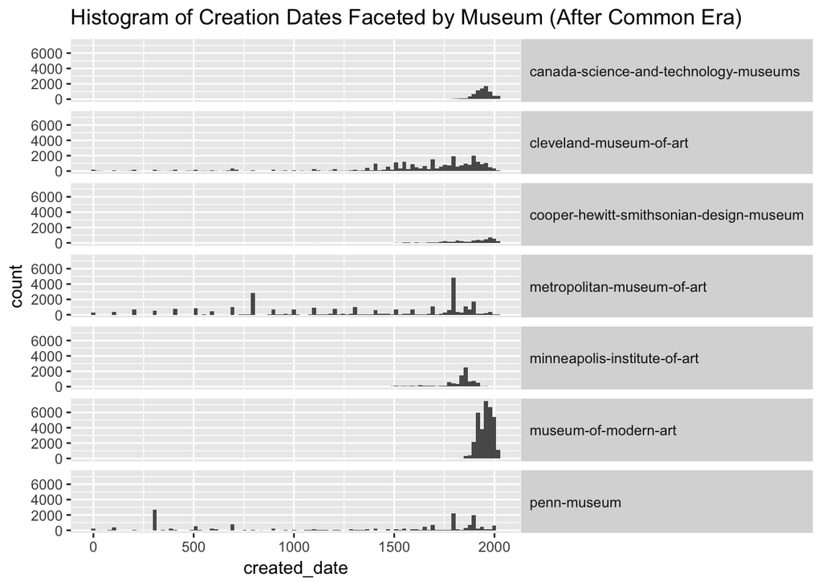

```r
ggplot(museum_data_abs, aes(x=created_date)) + geom_histogram(bins = 100) + labs(title = "Histogram of Creation Dates Faceted by Museum (After Common Era)") + facet_grid(museum ~ .) +
    theme(strip.text.y = element_text(angle = 0, hjust = 0))
```

From these histograms, we can see several interesting patterns or characteristics of the data. For one, we can see that both the Canada Science and Tech Museums and the MOMA have artifacts that are exclusively created within the last 200 years. We can also see that the collections for the Cooper-Hewitt and the Minneapolis Institute have relatively recently created collections, spanning back to about 500 years ago.

Additionally, we can see that with respect to the Cleveland Museum of Art, the Met, and the Penn Museum, while their collections are clustered closer to common day, they are in possession of artifacts that span back centuries and that it is likely these museums that posses artifacts that are dated to before the common era.

```r
museum_data_bc = subset(museum_data, created_date < 0)
```

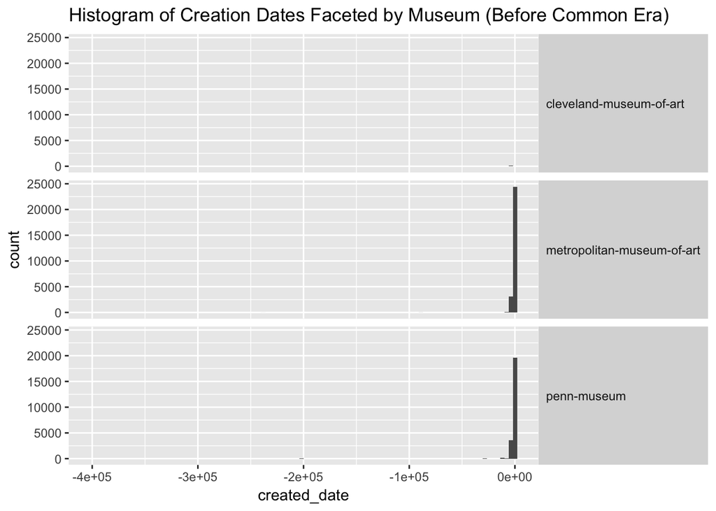

```r
ggplot(museum_data_bc, aes(x=created_date)) + geom_histogram(bins = 100) + labs(title = "Histogram of Creation Dates Faceted by Museum (Before Common Era)") + facet_grid(museum ~ .) +
    theme(strip.text.y = element_text(angle = 0, hjust = 0))
```

Subsetting the data to include only artifacts that were developed before the Common Era (B.C. or B.C.E), we can see that it was in fact the three museums from earlier that possess artifacts dating back to before the Common Era. However, these seem to date back to roughly 10,000 B.C. or earlier, with only a few artifacts dating back to earlier. Below, we plot the histogram for artifacts that date back to 10,000 B.C. or earlier, with a table of the remaining artifacts that date back earlier.

```r
museum_data_bc_10000 = subset(museum_data, created_date < 0 & created_date > -10000)
```

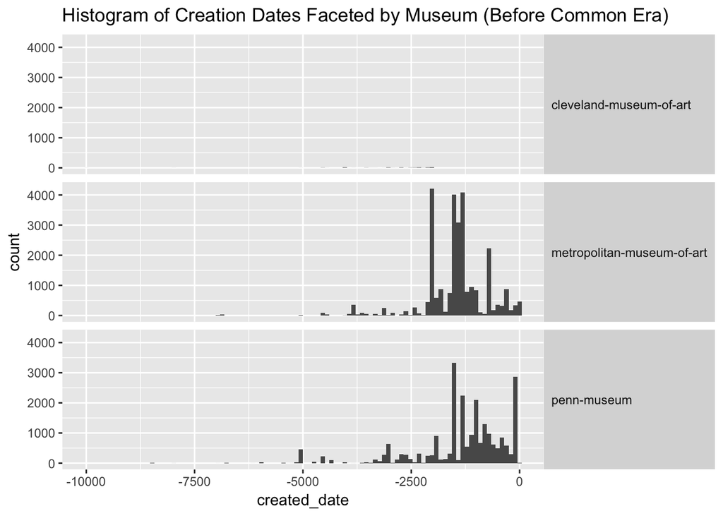

```r
ggplot(museum_data_bc_10000, aes(x=created_date)) + geom_histogram(bins = 100) + labs(title = "Histogram of Creation Dates Faceted by Museum (Before Common Era)") + facet_grid(museum ~ .) +
    theme(strip.text.y = element_text(angle = 0, hjust = 0))
```

```r
museum_data_pre_10000 = subset(museum_data, created_date < -10000)
count(museum_data_pre_10000, "museum")
```

```
##                       museum freq
## 1 metropolitan-museum-of-art   19
## 2                penn-museum  311
```

## Exploration of Acquisition Dates

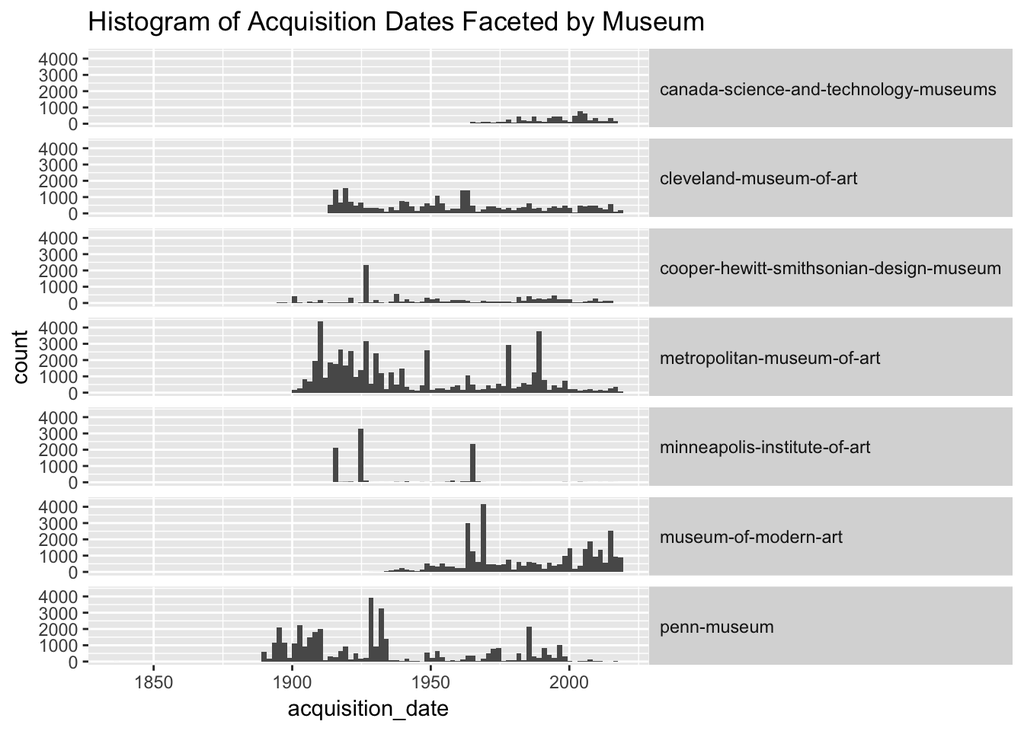

```r
ggplot(museum_data, aes(x=acquisition_date)) + geom_histogram(bins = 100) + labs(title = "Histogram of Acquisition Dates Faceted by Museum") + facet_grid(museum ~ .) +
    theme(strip.text.y = element_text(angle = 0, hjust = 0))
```